# Lab 2

Payton Schulte

2025-09-04

## Task 1 - Sorting Files into Directories

```r
getwd()
```

```
## [1] "/Users/paytonschulte/RPACKAGES/MATH4753F25paytonsch/R/Lab2"
```

## Task 2 - Reading Data into R

```r
# Reads in EPAGAS csv
mpg.df=read.csv("EPAGAS.csv")
head(mpg.df)
```

```
##    MPG
## 1 36.3
## 2 41.0
## 3 36.9
## 4 37.1
## 5 44.9
## 6 36.8
```

## Task 3 - Determining Outliers

```r
# Makes mpg data from csv a vector
mpg = mpg.df$MPG
head(mpg)
```

```
## [1] 36.3 41.0 36.9 37.1 44.9 36.8
```

> 1. Transformed mpg variable to z with varified results:

```r
# Transforms mpg variable to z
z=(mpg-mean(mpg))/sd(mpg)
head(z)
```

```
## [1] -0.28702628  1.65681163 -0.03887676  0.04383975  3.26978352 -0.08023501
```

```r
# Verifies that the mean of z is 0
mean(z)
```

```
## [1] 7.931156e-17
```

```r
# Verifies that the standard deviation of z is 1
sd(z)
```

```
## [1] 1
```

> 2. Values of mpg that are possible outliers: **30.0, 42.1, 31.8**

```r
mpg[abs(z)>=2 & abs(z)<=3]
```

```
## [1] 30.0 42.1 31.8
```

> 3. Values of mpg that are outliers: **44.9**

```r
mpg[abs(z)>3]
```

```
## [1] 44.9
```

> 4. Dataplot to detect outliers:

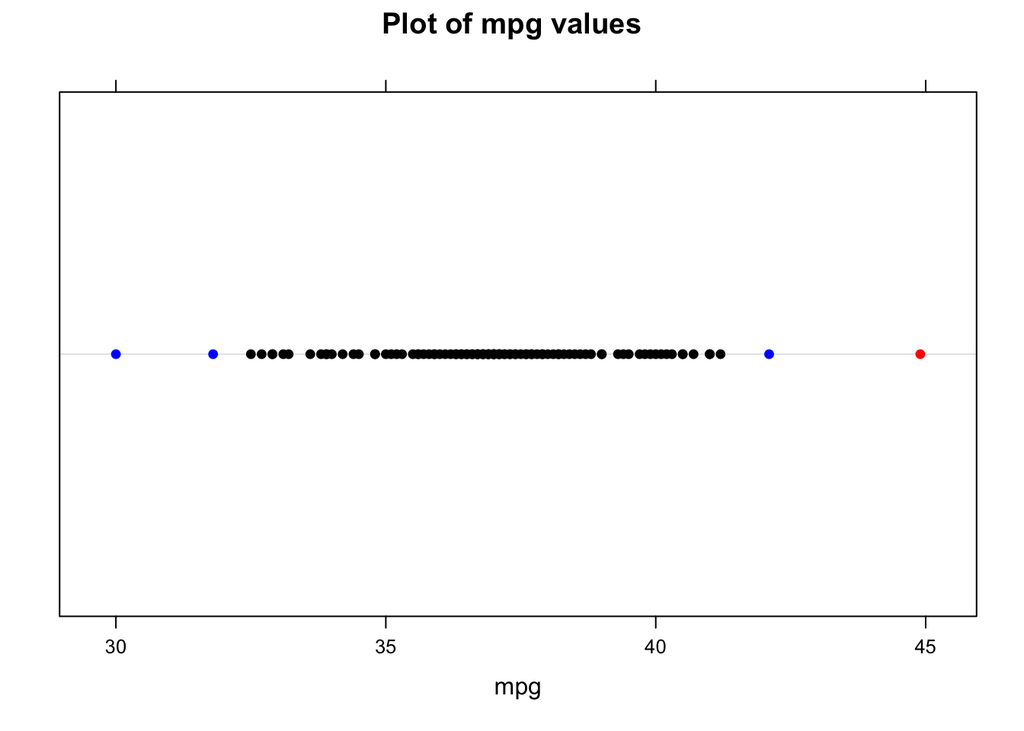

```r
# Color codes the outliers in red and the possible outliers in blue
mpg_plot = ifelse(abs(z)>3,"Red",ifelse(abs(z)>=2 &abs(z)<=3,"Blue","Black"))
# Installs lattice package
library(lattice)
dotplot(mpg, col=mpg_plot, main= "Plot of mpg values")
```

## Task 4 - Boxplot and Chebyshev’s Theorem

> 1. Boxplot of the mpg variable:

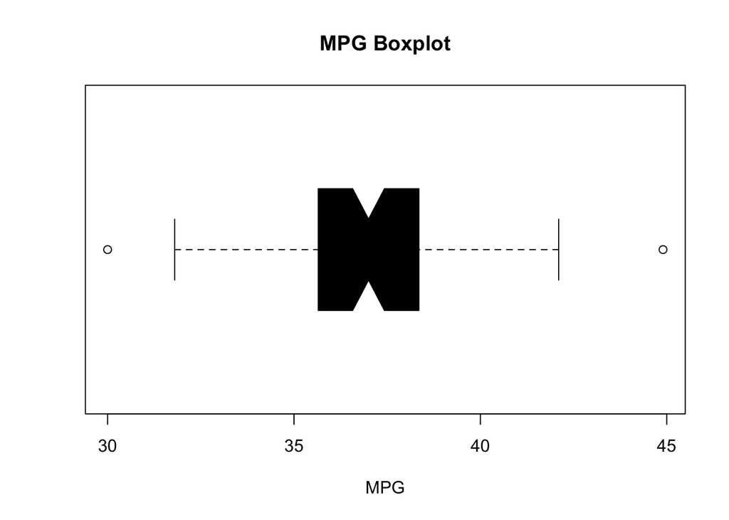

```r
# Boxplot with a black box, notch on the median, horizontal, and includes a title
boxplot(mpg, main="MPG Boxplot", xlab="MPG", col="black", horizontal=TRUE, notch=TRUE)
```

### Chebyshev’s Theorem: $1 - \frac{1}{k^2}$

> 2. Proportion of data within 2 standard deviations of the mean: **0.75**

```r
# Using k = 2
k=2
sd_prop = 1 - (1/(k^2))
sd_prop
```

```
## [1] 0.75
```

> 3. Exact proportion within 2 standard deviation of the mean: **0.96**

```r
# Using mpg data to find exact proportion within 2 standard deviations
exact_prop = length(mpg[abs(z)<2])/length(mpg)
exact_prop
```

```
## [1] 0.96
```

> 4. No, Chebyshev does not aagree with the data. Using the Chebyshev Theorem, 75% of the data should be within 2 standard deviations of the mean. However, when finding the exact proportion of data within 2 standard deviations of the mean using R and the mpg data, we get a result of 96%.

### Empirical Rule: 68–95–99.7

> 5. According to the empirical rule, 95% of the data should be within 2 standard deviations of the mean.
> 6. The empirical rule is very similar to the exact proportion of data within 2 standard deviations of the mean. The empirical rule expects 95% of the data to be found within 2 standard deviations, and in reality, 96% of the data could be found in that range. This shows a high correspondence between the empirical rule and reality.
> 7. The empirical rule is valid in this case. The empirical rule expects 68% of the data to be located within the 1 standard deviation of the mean, 95% to be within 2 standard deviations, and 99.7% to be within 3 standard deviations. When finding the exact proportions within those ranges using R and the mpg data, 68% of the data is located within 1 standard deviation of the mean, 96% within 2 standard deviations, and 99% within 3 standard deviations. This similarity proves that in this case, the empirical rule is valid.

```r
# Using mpg data to find exact proportion within 1 standard deviation
exact_prop = length(mpg[abs(z)<1])/length(mpg)
exact_prop
```

```
## [1] 0.68
```

```r
# Using mpg data to find exact proportion within 3 standard deviations
exact_prop = length(mpg[abs(z)<3])/length(mpg)
exact_prop
```

```
## [1] 0.99
```